# Wolf Moose Population Dynamics In Isle Royale

### Authors: The Quant Queens

#### Shreya Patel, Rewa Raizada, Erin Taylor

# Introduction

We are analyzing data collected on predator-prey interaction between wolves and moose on Isle Royale (Michigan), a closed ecosystem, emphasizing effects of climate change on population stability and interactions. Study aims to address gaps in current research by examining the interconnected effects of climate change on both species. In terms of its importance, it helps contribute to conservation strategies by offering predictive insight for managing isolated ecosystems and endangered spieces (such as the ongoing wolf reintroduction efforts).

The data we plan to analyze was collected by the Wolf-Moose Project in association with the National Parks Service. To begin, we will load in the data and clean it up for use.

```python
import os
os.getcwd()
```

```
'/Users/tabassumraizada/Documents/Biology301/Project/ProjectGitHub/isle-royal-population-dynamics/code'
```

```python
# pip install ipywidgets
```

```python
# the imports
import pandas as pd
import numpy as np
from scipy.integrate import odeint
from scipy.signal import find_peaks
from scipy.optimize import minimize
from scipy.stats import pearsonr
import scipy.stats as stats
import matplotlib.pyplot as plt

import ipywidgets as widgets
from IPython.display import display

import seaborn as sns

# extra packages for interactive plots
import holoviews as hv
import bokeh.io
import panel as pn

bokeh.io.output_notebook()
pn.extension('mathjax')
hv.extension('bokeh')
```

Loading BokehJS ...

```python
# load the data
file_path = "../data/Data_wolves_moose_Isle_Royale_June2019.xlsx"

# Read the first sheet
sheet_name = "1. population level data"
data = pd.read_excel(file_path, sheet_name=sheet_name, header=1)

# Display the first few rows
print(data.head(4))
```

[output not shown]

```python
# clean and prepare data
data_clean = data[['year', 'wolves', 'moose']].dropna()
data_clean['year'] = pd.to_numeric(data_clean['year'], errors='coerce')
data_clean['wolves'] = pd.to_numeric(data_clean['wolves'], errors='coerce')
data_clean['moose'] = pd.to_numeric(data_clean['moose'], errors='coerce')
data_clean = data_clean.dropna().reset_index(drop=True)
```

# Population vs Time

To get a feel for the population dynamics in Isle Royal, we begin by graphing population vs time.

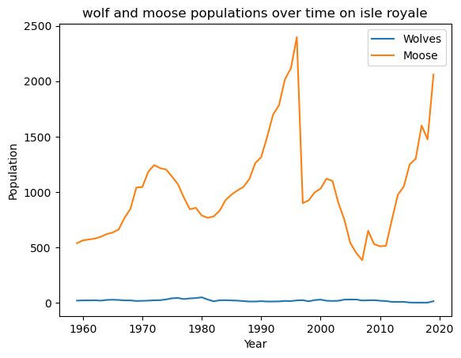

```python
# plot wolf and moose populations over time
plt.plot(data_clean["year"], data_clean["wolves"], label="Wolves")
plt.plot(data_clean["year"], data_clean["moose"], label="Moose")

plt.xlabel("Year")
plt.ylabel("Population")
plt.title("wolf and moose populations over time on isle royale")
plt.legend()
plt.show()
```

Here we notice it is difficult to visualize the population dynamics as the population of moose is significantly higher that that of the wolves. To correct for this, we will plot the populations on different y-axis.

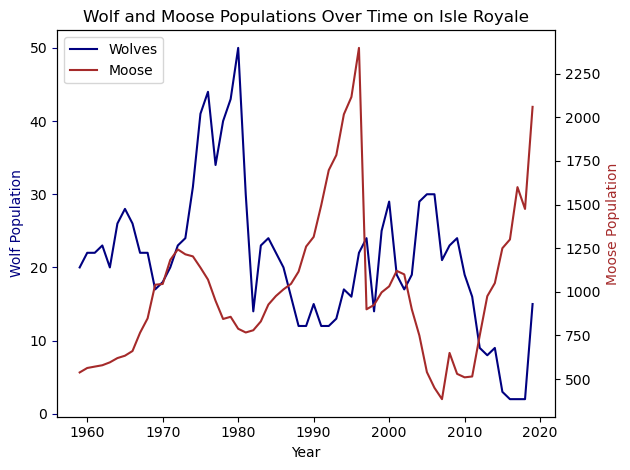

```python
# create the plot with two y-axes
fig, ax1 = plt.subplots()

# plot wolf population on the first y-axis
ax1.plot(data_clean["year"], data_clean["wolves"], color="navy", label="Wolves")
ax1.set_xlabel("Year")
ax1.set_ylabel("Wolf Population", color="navy")
ax1.tick_params(axis="y", color="navy")

# second y-axis for the moose population
ax2 = ax1.twinx()
ax2.plot(data_clean["year"], data_clean["moose"], color="brown", label="Moose")
ax2.set_ylabel("Moose Population", color="brown")
ax2.tick_params(axis="y")

lines1, labels1 = ax1.get_legend_handles_labels()
lines2, labels2 = ax2.get_legend_handles_labels()
plt.legend(lines1 + lines2, labels1 + labels2, loc="upper left")

plt.title("Wolf and Moose Populations Over Time on Isle Royale")

fig.tight_layout()
plt.show()
```

From this graph, we notice some ocillations in the two populations. This led us to experiment with the lotka-volterra model.

# First Attempt at Lotka-Voltera Model

To get started builing a preliminary version of this model, we used the equations: $$\frac{dM}{dt} = \alpha M - \beta MW$$ to model the moose population, with $\alpha$ as the growth rate of the moose, and $\beta$ being the predation rate coefficient to model the wolf population, we use $$\frac{dW}{dt} = \delta MW - \gamma W$$ with $\delta$ being the rate at which wolves reproduce based on eating moose and $\gamma$ being the death rate.

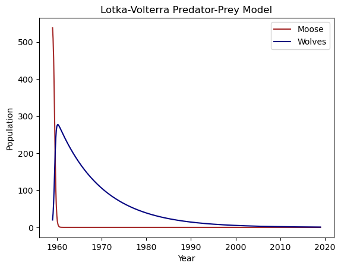

```python
# the Lotka-Volterra equations
def lotka_volterra(y, t, alpha, beta, delta, gamma):
    M, W = y
    dMdt = alpha * M - beta * M * W
    dWdt = delta * M * W - gamma * W
    return [dMdt, dWdt]

# initial populations
M0 = data_clean["moose"].iloc[0]
W0 = data_clean["wolves"].iloc[0]

# Parameters
alpha = 0.1   # Moose growth rate
beta = 0.02   # Predation rate
delta = 0.01  # Predator reproduction rate
gamma = 0.1   # Wolf death rate

# time points for the simulation
time = np.linspace(data_clean["year"].min(), data_clean["year"].max(), 500)

solution = odeint(lotka_volterra, [M0, W0], time, args=(alpha, beta, delta, gamma))

# extract solutions
moose_pop, wolf_pop = solution[:, 0], solution[:, 1]

# Plot
plt.plot(time, moose_pop, label="Moose", color="brown")
plt.plot(time, wolf_pop, label="Wolves", color="navy")
plt.xlabel("Year")
plt.ylabel("Population")
plt.title("Lotka-Volterra Predator-Prey Model")
plt.legend()
plt.show()
```

After this first attempt, we're not getting the results we hoped for. We believe this is because of the parameters. To help us in picking the idealized parameter, we include sliders.

```python
# Activate Panel extension
pn.extension()

# Parameters
#alpha (prey growth rate): Controls how quickly the prey population grows in the absence of predators.
#beta (predation rate): Determines how strongly the predators affect the prey population.
#delta (predator reproduction rate): Dependent on prey consumption.
#gamma (predator death rate): Reflects the natural death of predators without sufficient prey.


# Lotka-Volterra function
def lotka_volterra(y, t, alpha, beta, delta, gamma):
    M, W = y
    dMdt = alpha * M - beta * M * W
    dWdt = delta * M * W - gamma * W
    return [dMdt, dWdt]

# initial populations
M0 = data_clean["moose"].iloc[0]
W0 = data_clean["wolves"].iloc[0]

# time span for simulation
time = np.linspace(data_clean["year"].min(), data_clean["year"].max(), 500)

# function to update the plot dynamically
def update_plot(alpha, beta, delta, gamma):
    solution = odeint(lotka_volterra, [M0, W0], time, args=(alpha, beta, delta, gamma))
    moose_pop, wolf_pop = solution[:, 0], solution[:, 1]

    plt.figure(figsize=(10, 5))
    plt.plot(time, moose_pop, label="Moose (Prey)", color="brown")
    plt.plot(time, wolf_pop, label="Wolves (Predator)", color="navy")
    plt.xlabel("Year")
    plt.ylabel("Population")
    plt.title("Interactive Lotka-Volterra Model")
    plt.legend()
    plt.show()

# Function to plot the results
def plot_lotka_volterra(alpha, beta, delta, gamma):
    y0 = [500, 25]
    t = np.linspace(0, 200, 5000)
    #solution = odeint(lotka_volterra, y0, t, args=(alpha, beta, delta, gamma))
    solution = odeint(lotka_volterra, [M0, W0], time, args=(alpha, beta, delta, gamma))
    fig, ax = plt.subplots(figsize=(6, 3))
    ax.plot(time, solution[:, 0], label="Moose (Prey)", color="brown")
    ax.plot(time, solution[:, 1], label="Wolves (Predator)", color="navy")
    ax.legend()
    ax.set_xlabel('Year')
    ax.set_ylabel('Population')
    ax.set_title('Interactive Lotka-Volterra Model')
    ax.grid(True)
    plt.close(fig)  # Prevents double plotting
    return fig

# create sliders for each parameter

alpha_slider = pn.widgets.FloatSlider(name="α (Moose Growth)", start=0.001, end=1.0, step=0.01, value=0.1)
beta_slider = pn.widgets.FloatSlider(name="β (Predation)", start=0.001, end=0.1, step=0.001, value=0.02)
delta_slider = pn.widgets.FloatSlider(name="δ (Wolf Reproduction)", start=0.001, end=0.1, step=0.001, value=0.01)
gamma_slider = pn.widgets.FloatSlider(name="γ (Wolf Death)", start=0.001, end=1.0, step=0.01, value=0.1)

# Display interactive plot with sliders
#widgets.interactive(update_plot, alpha=alpha_slider, beta=beta_slider, delta=delta_slider, gamma=gamma_slider)

# Bind sliders to the plotting function
# Use Matplotlib Pane to refresh the plot dynamically
interactive_plot = pn.bind(lambda alpha, beta, delta, gamma: pn.pane.Matplotlib(plot_lotka_volterra(alpha, beta, delta, gamma), tight=True),
                           alpha=alpha_slider, beta=beta_slider, delta=delta_slider, gamma=gamma_slider)

pn.Column(alpha_slider, beta_slider, delta_slider, gamma_slider, interactive_plot).servable()
```

```
oscillations found: α=0.15, β=0.0064444444444444445, δ=0.001, γ=0.4
```

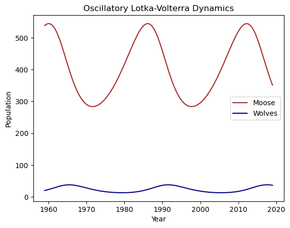

```python
# Lotka-Volterra function
def lotka_volterra(y, t, alpha, beta, delta, gamma):
    M, W = y
    dMdt = alpha * M - beta * M * W
    dWdt = delta * M * W - gamma * W
    return [dMdt, dWdt]

# initial populations
M0 = data_clean["moose"].iloc[0]
W0 = data_clean["wolves"].iloc[0]
initial_conditions = [M0, W0]

# time span for simulation
time = np.linspace(data_clean["year"].min(), data_clean["year"].max(), 500)

# function to test for oscillations
def test_oscillations(alpha, beta, delta, gamma):
    solution = odeint(lotka_volterra, initial_conditions, time, args=(alpha, beta, delta, gamma))
    moose_pop, wolf_pop = solution[:, 0], solution[:, 1]

    # find peaks in both populations to check for oscillations
    moose_peaks, _ = find_peaks(moose_pop)
    wolf_peaks, _ = find_peaks(wolf_pop)

    # return True if both have multiple peaks
    return len(moose_peaks) > 2 and len(wolf_peaks) > 2

# automated search for oscillatory parameters
def find_oscillatory_params():
    alpha_values = np.linspace(0.15, 0.5, 10)
    beta_values = np.linspace(0.001, 0.05, 10)
    delta_values = np.linspace(0.001, 0.05, 10)
    gamma_values = np.linspace(0.05, 0.5, 10)

    for alpha in alpha_values:
        for beta in beta_values:
            for delta in delta_values:
                for gamma in gamma_values:
                    if test_oscillations(alpha, beta, delta, gamma):
                        print(f"oscillations found: α={alpha}, β={beta}, δ={delta}, γ={gamma}")
                        return alpha, beta, delta, gamma
    return None

# find parameters and plot
params = find_oscillatory_params()
if params:
    alpha, beta, delta, gamma = params
    solution = odeint(lotka_volterra, initial_conditions, time, args=(alpha, beta, delta, gamma))
    moose_pop, wolf_pop = solution[:, 0], solution[:, 1]

    # Plot
    plt.plot(time, moose_pop, label="Moose", color="brown")
    plt.plot(time, wolf_pop, label="Wolves", color="navy")
    plt.xlabel("Year")
    plt.ylabel("Population")
    plt.title("Oscillatory Lotka-Volterra Dynamics")
    plt.legend()
    plt.show()
else:
    print("no oscillations :-(")
```

Having gotten these parameter values, lets replot the lotka voltera model with different starting populations and larger time span.

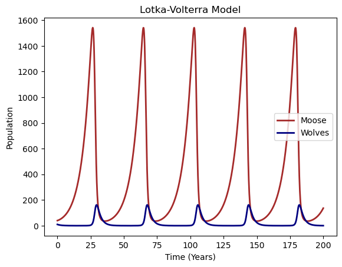

```python
# Lotka-Volterra function
def lotka_volterra(y, t, alpha, beta, delta, gamma):
    M, W = y
    dMdt = alpha * M - beta * M * W
    dWdt = delta * M * W - gamma * W
    return [dMdt, dWdt]

# parameters from the search
alpha = 0.15000000000000002
beta = 0.0064444444444444445
delta = 0.001
gamma = 0.4

# initial populations
M0 = 40  # Start with a low moose population
W0 = 10  # Start with a relatively high wolf population
initial_conditions = [M0, W0]

# extended time span for more oscillations
time = np.linspace(0, 200, 1000)
#time = np.linspace(data_clean["year"].min(), data_clean["year"].max(), 500)

# solve the Lotka-Volterra equations
solution = odeint(lotka_volterra, initial_conditions, time, args=(alpha, beta, delta, gamma))
moose_pop, wolf_pop = solution[:, 0], solution[:, 1]

# plot the populations over time
plt.plot(time, moose_pop, label="Moose", color="brown", linewidth=2)
plt.plot(time, wolf_pop, label="Wolves", color="navy", linewidth=2)

plt.xlabel("Time (Years)")
plt.ylabel("Population")
plt.title("Lotka-Volterra Model")
plt.legend()
plt.show()
```

The Lotka-Volterra model generated here illustrates the classic predator-prey dynamics, where the moose population and wolf population oscillate in response to each other's growth and decline. The model demonstrates that predator populations lag behind prey populations, with drastic peaks showing the cyclical nature of population growth and collapse. It implies that in a closed ecosystem, predator-prey interactions can create recurring cycles of abundance and scarcity. However, the model operates under several key assumptions: it assumes constant environmental conditions, no migration, and linear interactions between the species (predation rate and reproduction are directly proportional). Real ecosystems are more complex, with factors like climate change, resource availability, and stochastic events influencing population dynamics, making this an idealized representation of predator-prey interactions.

# Modified Lotka-Volterra Model

To try and make our model more representative of the actual complexity of the ecosystem, we want to take into consideration some of the real-world events that happened to these populations.

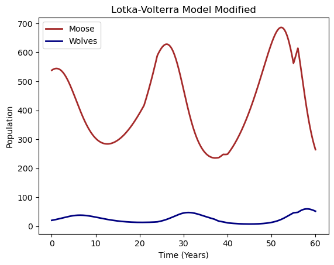

```python
# Lotka-Volterra function
def mod_lotka_volterra(y, t, alpha, beta, delta, gamma):
    M, W = y

    # real-world events
    if 21 <= t < 24:  # wolf crash due to parvovirus (1980-1982)
        W *= 0.4
    if 37 <= t < 38:  # moose collapse due to winter/ticks (1996-1997)
        M *= 0.3
    if 39 <= t < 40:  # wolf immigration (1997-1998)
        W += 10
    if 55 <= t < 56:  # wolf crash around 2015
        W *= 0.2

    dMdt = alpha * M - beta * M * W
    dWdt = delta * M * W - gamma * W
    return [dMdt, dWdt]

# parameters from the search
alpha = 0.15000000000000002
beta = 0.0064444444444444445
delta = 0.001
gamma = 0.4

M0, W0 = 538, 20  # initial populations from 1959
initial_conditions = [M0, W0]

# time of 60 years to reflect the data
time = np.linspace(0, 60, 600)

# solve the Lotka-Volterra equations
solution = odeint(mod_lotka_volterra, initial_conditions, time, args=(alpha, beta, delta, gamma))
moose_pop, wolf_pop = solution[:, 0], solution[:, 1]

# plot the populations over time
plt.plot(time, moose_pop, label="Moose", color="brown", linewidth=2)
plt.plot(time, wolf_pop, label="Wolves", color="navy", linewidth=2)

plt.xlabel("Time (Years)")
plt.ylabel("Population")
plt.title("Lotka-Volterra Model Modified")
plt.legend()
plt.show()
```

Lets also generalize this model with idealized parameters and a larger time span.

```
oscillations found: α=0.05, β=0.001, δ=0.001, γ=0.15000000000000002
```

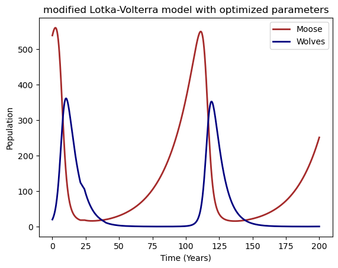

```python
time = np.linspace(0, 200, 1000)

# function to test for oscillations with modified model
def test_oscillations_mod(alpha, beta, delta, gamma):
    solution = odeint(mod_lotka_volterra, initial_conditions, time, args=(alpha, beta, delta, gamma))
    moose_pop, wolf_pop = solution[:, 0], solution[:, 1]

    # Use smoothed populations to detect peaks
    moose_peaks, _ = find_peaks(np.convolve(moose_pop, np.ones(10)/10, mode='same'))
    wolf_peaks, _ = find_peaks(np.convolve(wolf_pop, np.ones(10)/10, mode='same'))

    # return True if both have multiple peaks
    return len(moose_peaks) > 2 and len(wolf_peaks) > 2

# search for oscillatory parameters with modified model
def find_oscillatory_params_mod():
    alpha_values = np.linspace(0.05, 0.5, 10)
    beta_values = np.linspace(0.001, 0.05, 10)
    delta_values = np.linspace(0.001, 0.05, 10)
    gamma_values = np.linspace(0.05, 0.5, 10)

    for alpha in alpha_values:
        for beta in beta_values:
            for delta in delta_values:
                for gamma in gamma_values:
                    if test_oscillations_mod(alpha, beta, delta, gamma):
                        print(f"oscillations found: α={alpha}, β={beta}, δ={delta}, γ={gamma}")
                        return alpha, beta, delta, gamma
    return None

# find parameters
params_mod = find_oscillatory_params_mod()
if params_mod:
    alpha, beta, delta, gamma = params_mod
    solution = odeint(mod_lotka_volterra, initial_conditions, time, args=(alpha, beta, delta, gamma))
    moose_pop, wolf_pop = solution[:, 0], solution[:, 1]

    # Plot
    plt.plot(time, moose_pop, label="Moose", color="brown", linewidth=2)
    plt.plot(time, wolf_pop, label="Wolves", color="navy", linewidth=2)

    plt.xlabel("Time (Years)")
    plt.ylabel("Population")
    plt.title("modified Lotka-Volterra model with optimized parameters")
    plt.legend()
    plt.show()
else:
    print("no oscillations found :-(")
```

The moose peaks occur a few years before the wolves, illustrating the classic lag in predator-prey interactions. Moose populations grow first due to lower predation pressure, followed by wolf population increases driven by prey abundance. This was seen in both the original and modified models. These oscillations highlight the cyclical nature of their relationship, where the predator depends on prey availability, and over-predation ultimately limits both populations.

The inclusion of real-world events like wolf crashes (parvovirus outbreaks), moose collapses (severe winters/ticks), and wolf immigration adds a realistic layer to the model. These disruptions demonstrate stressors can shift population dynamics, with temporary prey recoveries or predator rebounds shaping the oscillations. The model underscores the fragility of isolated ecosystems like Isle Royale, where external factors and small population sizes can have major effects.

Overall, the model provides valuable insight into the interdependence of wolves and moose. Its predictive power can inform conservation strategies, such as managing reintroductions or preparing for climate impacts, by anticipating the delayed but significant effects of interventions.

# Moose-Wolf Density Relation

Having modeled the populations, lets examine the densities of wolves and moose over time, we can assess whether their relationship aligns with classic ecological models, such as top-down (predator-driven) or bottom-up (resource-driven) control mechanisms. This section explores the density data and trends before and after 1980—a pivotal year marked by the introduction of canine parvovirus, which significantly impacted wolf populations—to better understand the complexities of these predator-prey interactions.

```python
# preprocess
data_clean = data[['year', 'wolves', 'moose']].dropna()
data_clean['year'] = pd.to_numeric(data_clean['year'], errors='coerce')
data_clean['wolves'] = pd.to_numeric(data_clean['wolves'], errors='coerce')
data_clean['moose'] = pd.to_numeric(data_clean['moose'], errors='coerce')
data_clean = data_clean.dropna().reset_index(drop=True)

# calculate densities (population per km²)
data_clean['Wolf_Density'] = data_clean['wolves'] / 544  # Wolves per km²
data_clean['Moose_Density'] = data_clean['moose'] / 544  # Moose per km²

# scale wolf density to per 1000 km² for easier comparison
data_clean['Wolf_Density_scaled'] = data_clean['Wolf_Density'] * 1000  # Wolves per 1000 km²
```

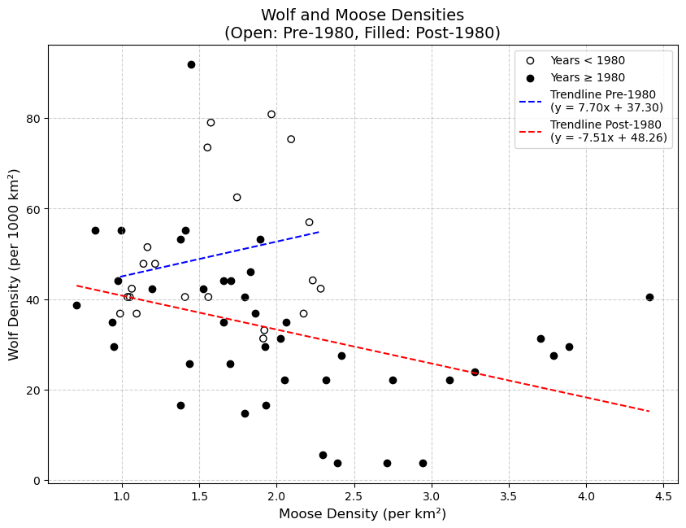

```python
# split data into years before and after 1980
pre_1980 = data[data['year'] < 1980]
post_1980 = data[data['year'] >= 1980]

# create the scatter plot
plt.figure(figsize=(10, 7))

# plot data for years before 1980 (open circles)
plt.scatter(pre_1980['Moose_Density'], pre_1980['Wolf_Density_scaled'],
            facecolors='none', edgecolors='black', label='Years < 1980')

# plot data for years after 1980 (filled circles)
plt.scatter(post_1980['Moose_Density'], post_1980['Wolf_Density_scaled'],
            color='black', label='Years ≥ 1980')

plt.xlabel('Moose Density (per km²)', fontsize=12)
plt.ylabel('Wolf Density (per 1000 km²)', fontsize=12)
plt.title('Wolf and Moose Densities\n(Open: Pre-1980, Filled: Post-1980)', fontsize=14)

# fit a linear regression model for years before 1980
z_pre = np.polyfit(pre_1980['Moose_Density'], pre_1980['Wolf_Density_scaled'], 1)
trendline_pre = np.poly1d(z_pre)

# fit a linear regression model after 1980
z_post = np.polyfit(post_1980['Moose_Density'], post_1980['Wolf_Density_scaled'], 1)
trendline_post = np.poly1d(z_post)

#trendlines
x_pre = np.linspace(pre_1980['Moose_Density'].min(), pre_1980['Moose_Density'].max(), 500)
x_post = np.linspace(post_1980['Moose_Density'].min(), post_1980['Moose_Density'].max(), 500)

plt.plot(x_pre, trendline_pre(x_pre), color='blue', linestyle='--',
         label=f'Trendline Pre-1980\n(y = {z_pre[0]:.2f}x + {z_pre[1]:.2f})')
plt.plot(x_post, trendline_post(x_post), color='red', linestyle='--',
         label=f'Trendline Post-1980\n(y = {z_post[0]:.2f}x + {z_post[1]:.2f})')

plt.legend()
plt.grid(True, linestyle='--', alpha=0.6)
plt.show()
```

```python
# Calculate correlation and p-value for pre-1980
corr_pre, p_value_pre = stats.pearsonr(pre_1980['Moose_Density'], pre_1980['Wolf_Density_scaled'])

# Calculate correlation and p-value for post-1980
corr_post, p_value_post = stats.pearsonr(post_1980['Moose_Density'], post_1980['Wolf_Density_scaled'])

# Print the results
print(f"Pre-1980 Correlation: {corr_pre:.3f}, P-value: {p_value_pre:.3e}")
print(f"Post-1980 Correlation: {corr_post:.3f}, P-value: {p_value_post:.3e}")
```

```
Pre-1980 Correlation: 0.228, P-value: 3.197e-01
Post-1980 Correlation: -0.390, P-value: 1.281e-02
```

Each dot on the graph represents the density of moose and wolves, with open circles for years prior to 1980 and black circles for years after 1980. The year 1980 marks an important tipping point in the wolf-moose dynamics, likely influenced by the introduction of canine parvovirus.

The wolf and moose densities are calculated by dividing the total number of wolves and moose on Isle Royale by the island's area (544 km²).

The analysis of correlation between wolf and moose densities before and after 1980 reveals distinct patterns:

Pre-1980: The correlation coefficient is 0.228 with a p-value of 0.3197. This suggests a weak positive correlation between wolf and moose densities in the pre-1980 period. However, the p-value is greater than the conventional threshold of 0.05, indicating that this correlation is not statistically significant. Therefore, we cannot confidently conclude that wolf abundance was strongly related to moose abundance in this period.

Post-1980: The correlation coefficient is -0.390 with a p-value of 0.01281. This indicates a moderate negative correlation between wolf and moose densities after 1980, and the p-value is less than 0.05, which is statistically significant. This suggests that after 1980, wolf populations may have been more strongly related to moose abundance, potentially due to increased predation pressure. This supports the idea of a top-down control on the food chain, where wolf populations are influenced by the availability of moose, but it still does not fully confirm a direct predation effect.

Overall, the graph suggests that the relationship between wolf and moose populations is not entirely explained by a simple top-down or bottom-up model. While the post-1980 data shows a statistically significant negative correlation, the weaker, non-significant pre-1980 correlation implies that the dynamics are more complex and influenced by additional factors beyond just predator-prey interactions. Thus, fluctuations in wolf and moose populations on Isle Royale likely reflect a combination of ecological factors, not solely predation or food availability.

# Factoring In Climate

In addition to moose and wolf populations, our data set reported multiple addtional values, which can be seen in the table below.

```python
data.head()
```

|  | year | wolves | moose | kill rate | predation rate | f (wolves) | ancestry (immigrant wolf) | Juvenile Survival | Adult Survival | overall survival (genetic-CR) | ... | Apr-May (temp, F) | Jan-Feb (temp, F) | May-Aug (precip, inches) | NAO (DJFM - station based) | NAO - annual | snow.depth (cm) | ice bridges (0=none, 1 = present) | springtime growing degree days | Unnamed: 33 | Unnamed: 34 |
| --- | --- | --- | --- | --- | --- | --- | --- | --- | --- | --- | --- | --- | --- | --- | --- | --- | --- | --- | --- | --- | --- |
| 0 | 1959.0 | 20.0 | 538.0 | NaN | NaN | NaN | NaN | NaN | NaN | NaN | ... | 43.9 | 1.40 | 16.8 | -0.37 | 1.83 | NaN | 0.0 | N/A yet | NaN | NaN |
| 1 | 1960.0 | 22.0 | 564.0 | NaN | NaN | NaN | NaN | NaN | NaN | NaN | ... | 43.4 | 8.45 | 12.08 | -1.54 | -1.88 | NaN | 0.0 | N/A yet | NaN | NaN |
| 2 | 1961.0 | 22.0 | 572.0 | NaN | NaN | NaN | NaN | NaN | NaN | NaN | ... | 41.4 | 9.75 | 8.94 | 1.8 | 0.47 | NaN | 1.0 | N/A yet | NaN | NaN |
| 3 | 1962.0 | 23.0 | 579.0 | NaN | NaN | NaN | NaN | NaN | NaN | NaN | ... | 42.6 | 2.15 | 16.01 | -2.38 | -1.05 | NaN | 1.0 | N/A yet | NaN | NaN |
| 4 | 1963.0 | 20.0 | 596.0 | NaN | NaN | NaN | NaN | NaN | NaN | NaN | ... | 43.5 | -0.35 | 14.1 | -3.6 | -2.16 | NaN | 1.0 | N/A yet | NaN | NaN |

5 rows × 35 columns

We were particularly interested in exploring the impact of climate on predator-prey dynamics because climate change has the potential to disrupt population stability and alter species interactions in isolated ecosystems like Isle Royale. Additionally, temperatures were readily recorded throughout the duration of the data, with new null values. Temperature fluctuations, in particular, can influence key biological processes such as reproduction, survival rates, and food availability, which are crucial for understanding the long-term viability of both wolves and moose. By focusing initially on temperature, we aim to determine how changes in climate may correlate with shifts in population dynamics.

```python
# a bit more preprocessing with our temp data
data = data.rename(columns={
    'July-Sept (temp, F)': 'July_Sept_Temp',
    'Apr-May (temp, F)': 'Apr_May_Temp',
    'Jan-Feb (temp, F)': 'Jan_Feb_Temp',
    'kill rate': 'Kill_Rate',
    'year': 'Year',
    'wolves': 'Wolves',
    'moose': 'Moose'
})

# convert temperature columns to numeric, forcing errors to NaN
temp_columns = ['July_Sept_Temp', 'Apr_May_Temp', 'Jan_Feb_Temp']
for col in temp_columns:
    data[col] = pd.to_numeric(data[col], errors='coerce')

# round temperature columns to the hundredths place
data[temp_columns] = data[temp_columns].round(2)
```

To get started exploring the impact that temperature has on population, we will plot the populations of both moose and wolvesagainst temperature to see if there is any correlation.

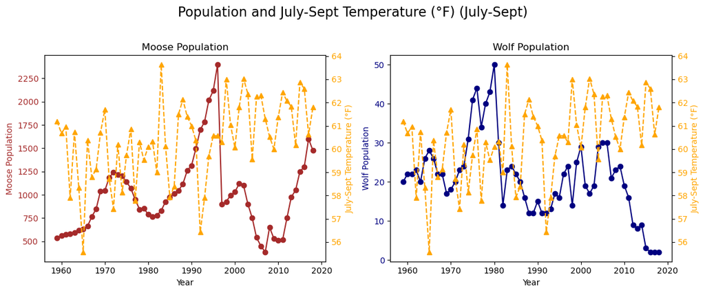

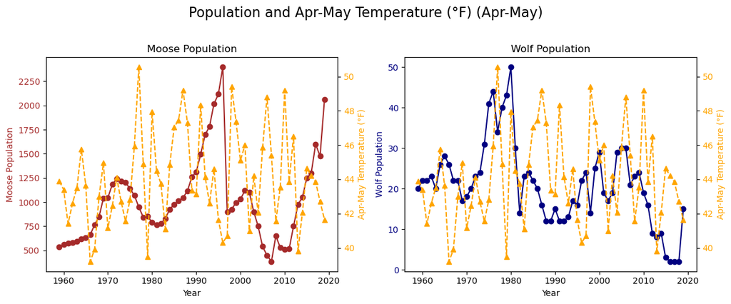

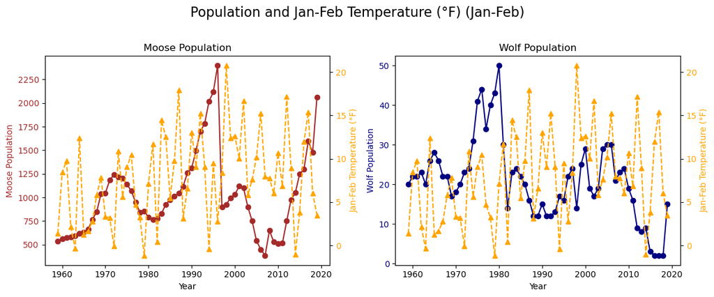

```python
# function to create plot
def population_vs_temperature_plots(data, temp_column, temp_label, title_suffix):
    # remove rows with NaN values in the specified temperature column
    filtered_data = data.dropna(subset=[temp_column])

    years = filtered_data['Year']
    moose_population = filtered_data['Moose']
    wolf_population = filtered_data['Wolves']
    temperature = filtered_data[temp_column]

    # subplots
    fig, axes = plt.subplots(1, 2, figsize=(12, 5))
    fig.suptitle(f"Population and {temp_label} ({title_suffix})", fontsize=16)

    # moose plot
    ax1 = axes[0]
    ax1.plot(years, moose_population, color="brown", marker="o", label="Moose")
    ax1.set_title("Moose Population")
    ax1.set_xlabel("Year")
    ax1.set_ylabel("Moose Population", color="brown")
    ax1.tick_params(axis="y", labelcolor="brown")

    # moose temperature axis
    ax1_twin = ax1.twinx()
    ax1_twin.plot(years, temperature, color="orange", linestyle="--", marker="^", label=temp_label)
    ax1_twin.set_ylabel(temp_label, color="orange")
    ax1_twin.tick_params(axis="y", labelcolor="orange")

    # wolf plot
    ax2 = axes[1]
    ax2.plot(years, wolf_population, color="navy", marker="o", label="Wolves")
    ax2.set_title("Wolf Population")
    ax2.set_xlabel("Year")
    ax2.set_ylabel("Wolf Population", color="navy")
    ax2.tick_params(axis="y", labelcolor="navy")

    # wolf temperature axis
    ax2_twin = ax2.twinx()
    ax2_twin.plot(years, temperature, color="orange", linestyle="--", marker="^", label=temp_label)
    ax2_twin.set_ylabel(temp_label, color="orange")
    ax2_twin.tick_params(axis="y", labelcolor="orange")

    plt.tight_layout(rect=[0, 0, 1, 0.96])  # Adjust layout to fit the title
    plt.show()

# and make the plots
population_vs_temperature_plots(data, 'July_Sept_Temp', 'July-Sept Temperature (°F)', "July-Sept")
population_vs_temperature_plots(data, 'Apr_May_Temp', 'Apr-May Temperature (°F)', "Apr-May")
population_vs_temperature_plots(data, 'Jan_Feb_Temp', 'Jan-Feb Temperature (°F)', "Jan-Feb")
```

To better understand the relationship between temperature and populations, let plot for p-values.

```
  Population          Temperature Period  Pearson Coefficient   P-value
0      Moose  July-Sept Temperature (°F)            -0.102965  0.433702
1       Wolf  July-Sept Temperature (°F)            -0.286731  0.026341
2      Moose    Apr-May Temperature (°F)            -0.170809  0.188121
3       Wolf    Apr-May Temperature (°F)             0.066413  0.611079
4      Moose    Jan-Feb Temperature (°F)            -0.018887  0.885125
5       Wolf    Jan-Feb Temperature (°F)            -0.132430  0.308960
```

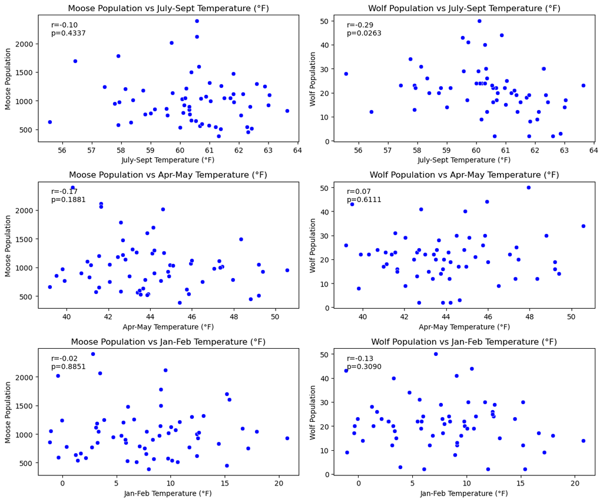

```python
# function to calculate correlation and prepare the plot
def calculate_correlation(data, temp_column, pop_column, temp_label, pop_label):
    #remove rows with NaN values in the specified columns
    filtered_data = data.dropna(subset=[temp_column, pop_column])

    temperature = filtered_data[temp_column]
    population = filtered_data[pop_column]

    #Pearson correlation
    corr_coeff, p_value = pearsonr(temperature, population)

    return corr_coeff, p_value, temperature, population
#,list to store results
results = []

# temperature periods and population groups
temperature_periods = [
    ('July_Sept_Temp', "July-Sept Temperature (°F)"),
    ('Apr_May_Temp', "Apr-May Temperature (°F)"),
    ('Jan_Feb_Temp', "Jan-Feb Temperature (°F)")
]
populations = [
    ('Moose', 'Moose Population'),
    ('Wolves', 'Wolf Population')
]

# plotting
fig, axes = plt.subplots(len(temperature_periods), len(populations), figsize=(12, 10))
fig.tight_layout(pad=4)

# loop over temperature periods and population groups
for row_idx, (temp_col, temp_label) in enumerate(temperature_periods):
    for col_idx, (pop_col, pop_label) in enumerate(populations):
        # Calc corelation
        corr_coeff, p_value, temperature, population = calculate_correlation(
            data, temp_col, pop_col, temp_label, pop_label
        )

        results.append([pop_label.split()[0], temp_label, corr_coeff, p_value])

        # plot
        ax = axes[row_idx, col_idx]
        sns.scatterplot(x=temperature, y=population, color="blue", ax=ax)
        ax.set_title(f"{pop_label} vs {temp_label}")
        ax.set_xlabel(temp_label)
        ax.set_ylabel(pop_label)
        ax.text(0.05, 0.95, f"r={corr_coeff:.2f}\np={p_value:.4f}",
                transform=ax.transAxes, fontsize=10, verticalalignment='top')

plt.tight_layout()

#DataFrame for the results
results_df = pd.DataFrame(
    results,
    columns=["Population", "Temperature Period", "Pearson Coefficient", "P-value"]
)

print(results_df)
```

Here we are looking for statistical significance in the correlation of temperature to populations. The Pearson correlation coefficient $r$ measures the strength and direction of a linear relationship between two variables, ranging from -1 (perfect negative correlation) to 1 (perfect positive correlation), with 0 indicating no linear relationship. The p-value assesses the statistical significance of this relationship, with values less than 0.05 suggesting the observed correlation is unlikely to occur by chance. A significant p-vaule indicates a meaningful association, while a non-significant p-value suggests the correlation may not be reliable or is due to random variation.

We are analyzing the relationship between temperature and population for moose and wolves across three seasonal temperature periods: July-September, April-May, and January-February.

For moose populations, the results showed no significant correlations with temperature. For July-September temperatures, the correlation coefficient was $r = -0.10$ with a p-value of 0.4337, indicating a weak negative relationship with no statistical significance. Similarly, April-May temperatures yielded $r = -0.17$ and $p = 0.1881$, and January-February temperatures produced $r = -0.02$ with $p = 0.8851$. These findings suggest that temperature alone does not meaningfully influence moose populations. Further analysis focusing on moose populations and temperature may not provide substantial insights unless additional variables are included.

For wolf populations, the results were slightly more compelling. A moderate negative correlation was observed between wolf population and July-September temperatures $r = -0.29$, $p = 0.0263$, suggesting a potential link where higher summer temperatures may correspond to lower wolf populations. This relationship is statistically significant and we could investigate further. In contrast, April-May temperatures showed a weak positive correlation $r = 0.07$, $p = 0.6111$, and January-February temperatures showed a weak negative correlation $r = -0.13$, $p = 0.3090$, neither of which were statistically significant.

While temperature does not appear to significantly influence moose populations, there may be a moderate relationship between summer temperatures and wolf populations. This could be due to ecological dynamics such as prey availability or hunting efficiency during warmer summers; however considering that there were no other correlations, we believe this statistical significance may just be coincedence. Further analysis with larger datasets or additional variables may help uncover meaningful patterns.

# Conclusion

In conclusion, our analysis of predator-prey dynamics between wolves and moose on Isle Royale reveals complex interactions. The Lotka-Volterra model provided a foundational understanding of these dynamics, illustrating the cyclical nature of predator-prey relationships. However, by incorporating real-world events such as wolf immigration, disease outbreaks, and environmental stressors like harsh winters and tick infestations, we were able to refine the model, reflecting the complexity of the ecosystem. The density analysis of moose and wolves revealed subtle changes in the correlation between their populations, especially after 1980, when the introduction of canine parvovirus impacted the wolf population. This shift suggests that predator-prey interactions on Isle Royale are influenced by more than just the abundance of one species affecting the other.

Furthermore, our investigation into the role of climate—specifically temperature—highlighted the nuanced effects of environmental factors on these populations. While temperature had minimal impact on moose populations, a moderate negative correlation between summer temperatures and wolf populations suggested that warmer summers could influence predator dynamics. However, the statistical significance of this relationship should be viewed with caution, as further analysis may be needed to identify other contributing variables.

These findings underscore the importance of understanding the intricate balance within closed ecosystems, especially in the face of climate change. As these ecosystems are highly sensitive to disruptions, including changes in climate, the predictive models we develop can aid in managing conservation efforts, such as wolf reintroductions and population monitoring. To gain more comprehensive insights, future studies could incorporate additional environmental factors (such as precipitation, snow cover, and food availability), as well as explore longer-term trends in climate data. Expanding the scope of analysis with more variables and larger datasets could offer deeper insights into how climate change is reshaping predator-prey relationships and ecosystem stability, providing valuable guidance for conservation management strategies in the future.